# Connect workspaces with run triggers

HCP Terraform's run triggers allow you to link workspaces so that a successful apply in a source workspace will queue a run in the workspace linked to it with a run trigger. For example, adding new subnets to your network configuration could trigger an update to your application configuration to rebalance servers across the new subnets.

When managing complex infrastructure with HCP Terraform, organizing your configuration into different workspaces helps you to better manage and design your infrastructure. Configuring run triggers between workspaces allows you to set up infrastructure pipelines as part of your overall deployment strategy.

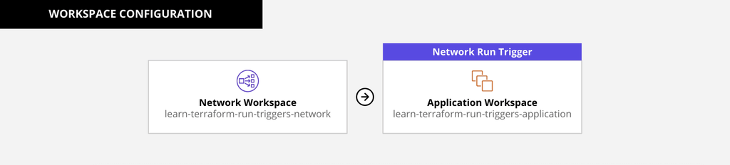

## Prerequisites

This tutorial assumes that you are familiar with the Terraform and HCP Terraform workflows. If you are new to Terraform, complete the Get Started collection first. If you are new to HCP Terraform, complete the HCP Terraform Get Started tutorials first.

In order to complete this tutorial, you will need the following:

- Terraform v1.2+ installed locally.
- An [AWS account](https://portal.aws.amazon.com/billing/signup?nc2=h_ct&src=default&redirect_url=https%3A%2F%2Faws.amazon.com%2Fregistration-confirmation#/start).
- An [HCP Terraform account](https://app.terraform.io/public/signup/account?utm_source=learn) with HCP Terraform locally authenticated.
- An HCP Terraform variable set configured with your AWS credentials.

Warning

There may be some charges from AWS associated with running this configuration. Please refer to the [AWS pricing guide](https://aws.amazon.com/elasticloadbalancing/pricing/) for more details. Instructions to remove the infrastructure you create can be found at the end of this tutorial.

## Fork GitHub repositories

This tutorial uses two GitHub repositories, one for each workspace, which you will need to fork to use with your HCP Terraform account.

### Network Repository

Navigate to the [network repository](https://github.com/hashicorp-education/learn-terraform-run-triggers-network). Use the **Fork** button in the upper right corner of that page to fork that repository into your account.

[figure not shown]

Inside this repository, you will find the Terraform configuration for your network infrastructure.

### Application Repository

Next, navigate to the [application repository](https://github.com/hashicorp-education/learn-terraform-run-triggers-application). Again, use the **Fork** button to fork this repository into your GitHub account.

The application repository is organized like the network repository, but with one important difference — this module uses a `terraform_remote_state` data block at the top of `main.tf` to retrieve the outputs from the network workspace. Remote state data blocks allow you to share data between workspaces in HCP Terraform. When used with the run trigger you will configure later in this tutorial, this data block will allow the application workspace to respond to changes to the network workspace.

```
data "terraform_remote_state" "network" {
  backend = "remote"

  config = {
    organization = var.tfc_org_name
    workspaces = {
          name = var.tfc_network_workspace_name
    }
  }
}
```

This data block resource will connect to HCP Terraform to retrieve output values from the indicated workspace, including the subnet and load balancer configuration. Later in `main.tf`, you can see that the `"aws_instance" "app"` resource uses this data to configure the correct subnet and security groups for each EC2 instance.

```
  subnet_id              = data.terraform_remote_state.network.outputs.private_subnet_ids[count.index % length(data.terraform_remote_state.network.outputs.private_subnet_ids)]
  vpc_security_group_ids = data.terraform_remote_state.network.outputs.app_instance_security_group_ids
```

Tip

We recommend using provider-specific data sources when convenient. `terraform_remote_state` is more flexible, but requires access to the whole Terraform state.

In the next section, you will create and configure workspaces for both of these repositories. Then, since the application infrastructure depends on the network infrastructure, you will set up a run trigger to connect them so that a change to your network infrastructure will reconfigure your application infrastructure as needed.

## Configure workspaces

Login to [HCP Terraform web UI](https://app.terraform.io/session?utm_source=learn). You may want to create an organization specifically for this example to separate it from any production infrastructure you are managing with HCP Terraform. You will need this organization name when configuring the application workspace.

### Network workspace

Create the network workspace by following these steps:

1. Navigate to **Workspaces** from the main menu, and click the **+ New Workspace** button.
2. Choose the **Version control workflow**.
3. Connect the workspace to your GitHub account. If you have not connected your GitHub account to HCP Terraform, follow the prompts to do so.
4. Connect to the `learn-terraform-run-triggers-network` GitHub repository you forked in the last step.
5. The workspace name will be `learn-terraform-run-triggers-network`. Leave the description blank.
6. Click the **Create Workspace** button.

Note

If this is the first time you have connected Terraform to GitHub, you will need to authenticate with GitHub first. Follow the prompts in HCP Terraform or refer to the Trigger HCP Terraform runs from VCS changes tutorial for instructions.

[figure not shown]

It will take a few moments for HCP Terraform to connect to GitHub and populate the workspace. While this process completes, click on **Go to workspace overview**, then choose **Variables** from the left nav.

[figure not shown]

### Application workspace

Now that you have configured the network workspace, create the application workspace by following a similar set of steps.

1. Navigate to **Workspaces** from the main menu, and click the **+ New Workspace** button in the upper right corner.
2. Choose the **Version control workflow**.
3. Connect the workspace to your GitHub account.
4. Connect to the `learn-terraform-run-triggers-application` GitHub repository you forked in the last step.
5. The workspace name will be `learn-terraform-run-triggers-application`. Leave the description blank.
6. Click the **Create Workspace** button.

Once you have created the application workspace, click on **Go to workspace overview**, then click **Variables**.

The remote state data block in the application configuration requires both the organization name and workspace name. It is set up to use the workspace name `learn-terraform-run-triggers-network` by default, but your organization name will be unique.

Click on the **+ Add variable** button and create a new Terraform Variable with the key `tfc_org_name`, and set the value to the name of your HCP Terraform or Terraform Enterprise organization. In the screenshot below, the organization name is "hashicorp-learn" — you will need to change this to your organization name.

[figure not shown]

Now you have two workspaces, one for your network and another for your application environment.

Next, you will configure a run trigger for the application workspace. Once the run trigger is configured, whenever the network workspace completes a successful apply step, a plan will automatically be queued in the application workspace.

## Allow remote state access

HCP Terraform protects your state file by encrypting it at rest and automatically restricting access to it from other workspaces. Allow the application workspace to access the network workspace's state.

1. Navigate to the `learn-terraform-run-triggers-network` workspace.
2. Select **Settings** from the main menu.
3. On the **General** page, scroll down to the **Remote state sharing** section.
4. Under **Select workspaces to share with** select `learn-terraform-run-triggers-application` from the drop-down menu.
5. Click the **Save settings** button at the bottom of the page.

[figure not shown]

## Configure a run trigger

Now configure a run trigger for the application workspace.

1. Navigate to the `learn-terraform-run-triggers-application` workspace.
2. Select **Settings** from the main menu.
3. Select **Run triggers** from the settings menu.
4. Under **Connected Workspaces**, click **Connect workspace**, select `learn-terraform-run-triggers-network` from the drop-down menu, and click **Connect**.

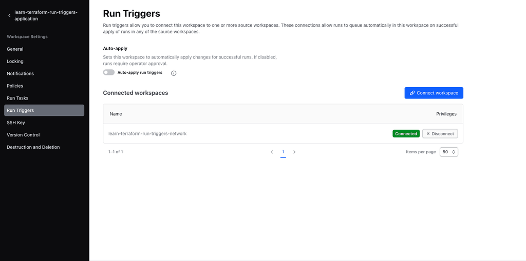

Now queue a plan for the network workspace.

1. Navigate to the `learn-terraform-run-triggers-network` workspace.
2. Select **Actions > Start a new run**.
3. Choose the **Plan and apply** run type.
4. Click the **Start run** button.

When the plan step is finished, there will be a message telling you that a successful apply step for this workspace will trigger a run for the `learn-terraform-run-triggers-application` workspace.

[figure not shown]

Click **Confirm & Apply** to apply the plan.

It will take a few minutes for the apply step to complete and the network resources to be provisioned.

[figure not shown]

Once the plan step is finished, click the **See details** button, then **Confirm & Apply** and **Confirm Plan** to apply the run. After the apply step is complete, click on the **> Outputs** interface to see the output values for this run. Copy the value shown for `public_dns_name` without the quotation marks and paste it in your web browser's address bar to see the "Hello, world!" message from the application.

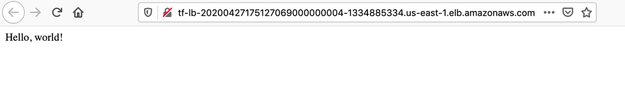

Now that you have set up a run trigger between your two workspaces, a successful apply on the network workspace will queue a plan on the application workspace. Additionally, if you want the application workspace to automatically apply runs after the network workspace, you can enable [auto-apply runs](https://developer.hashicorp.com/terraform/cloud-docs/workspaces/settings/run-triggers#run-triggers-auto-apply-setting) in the application workspace.

You can use run triggers to coordinate between workspaces as part of your infrastructure pipelines with other automation tools.

## Clean up

Destroy the infrastructure provisioned in these example workspaces to avoid unexpected charges from AWS. You must destroy this infrastructure in the correct order, because the VPC and associated infrastructure provisioned by the network workspace cannot be destroyed while there are EC2 instances provisioned by the application workspace which depend on it.

First, visit the application workspace. From the **Settings** menu, choose **Destruction and Deletion**. Ensure that **Allow destroy plans** is enabled. Next, click the **Queue destroy plan** button, and follow the steps to queue and confirm a destroy plan.

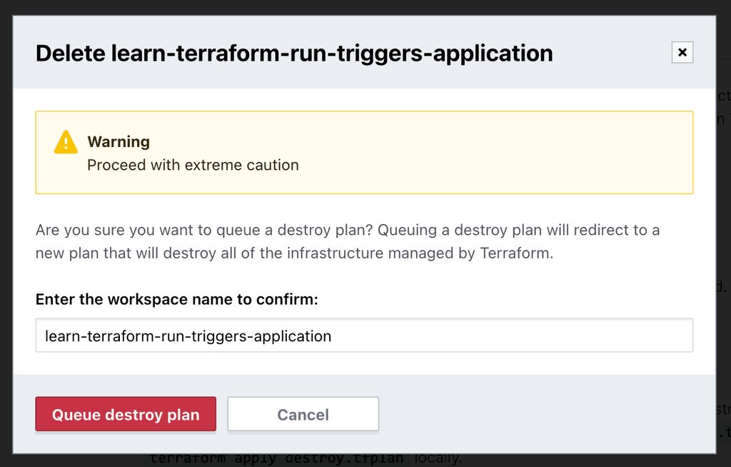

Once the destroy plan is complete, click **Confirm & Apply** followed by **Confirm Plan** to destroy your application resources.

Once the infrastructure has been successfully destroyed, return to the **Settings > Destruction and Deletion** page to delete the application workspace. Click the **Delete from HCP Terraform** button, and follow the prompt to delete your workspace from HCP Terraform.

Next, queue and apply a destroy plan for the network workspace by following the same steps. Once the infrastructure has been destroyed, delete the network workspace as well.

## Next Steps

Infrastructure and application developers have common goals including automating integration and application delivery pipelines. Run triggers are one of the ways HCP Terraform supports infrastructure pipelines to satisfy the unique needs of infrastructure teams.

### Further Reading

- Read more about run triggers and future plans for infrastructure pipelines in [this blog post](https://www.hashicorp.com/blog/creating-infrastructure-pipelines-with-terraform-cloud-run-triggers/).
- Learn more in the documentation for [run triggers](https://developer.hashicorp.com/terraform/cloud-docs/workspaces/settings/run-triggers) and Remote State data sources.
- See how to automate run triggers using the [HCP Terraform API](https://developer.hashicorp.com/terraform/cloud-docs/api-docs/run-triggers).
- Now that you are comfortable using run triggers, try a more in-depth tutorial and Deploy Consul and Vault on a Kubernetes Cluster using Run Triggers.

GitHub Actions

TFE provider

  Collaborate using HCP Terraform

  Collaborate on infrastructure with HCP Terraform. Follow these tutorials to migrate state from local storage and take a deeper look at HCP Terraform operations, including VCS integration, workspace configuration, and remote runs.

© 2026 HashiCorp  
Licensed under the MPL 2.0 License.  
https://developer.hashicorp.com/terraform/tutorials/automation/cloud-run-triggers